# turning point

liang kuang

April 12, 2017

## Turning points for oil price

In this R Markdown, it explores the Brend Spot Oil Price by trying to find the turning points from the time series. The first algorithm that experimented here is the most straigh-foward one, which defines a turning point as an event that has k consecutive change within the same direction and has momentum of at least above a threshold (In this case 5%).

```r
#Load the libraries
suppressPackageStartupMessages({
library('ggplot2')
library('zoo')
library('dplyr')
library('readr')
library('dygraphs')
library('xts')})
```

```r
# load the data
WTI_spot_price_IDDS <- read.csv("//was-2pbs01/Users/mfp53502/Projects/EEA/R/WTI_spot_price_IDDS.csv",header=TRUE,as.is=TRUE)
print(WTI_spot_price_IDDS$date[1])
```

```
## [1] "1/1/1990"
```

```r
WTI_spot_price_IDDS$date <- as.Date(WTI_spot_price_IDDS$date,"%m/%d/%Y")
str(WTI_spot_price_IDDS)
```

```
## 'data.frame':    855 obs. of  4 variables:
##  $ series_id : int  134253300 134253300 134253300 134253300 134253300 134253300 134253300 134253300 134253300 134253300 ...
##  $ date      : Date, format: "1990-01-01" "1990-02-01" ...
##  $ datavalue : num  21.2 19.9 18.4 16.5 16.3 ...
##  $ shortlabel: chr  "World, Price of Crude Oil: Brent, Units: US$ per barrel, Data source: Argus Media Limited, IMF" "World, Price of Crude Oil: Brent, Units: US$ per barrel, Data source: Argus Media Limited, IMF" "World, Price of Crude Oil: Brent, Units: US$ per barrel, Data source: Argus Media …
```

```r
#remove any NAs
WTI <- WTI_spot_price_IDDS[rowSums(is.na(WTI_spot_price_IDDS))==0,]
```

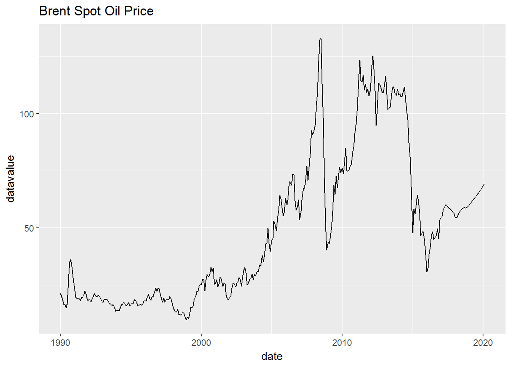

```r
# plot the WTI spot price
p1 <- ggplot() + geom_line(aes(y = datavalue, x = date,group = 1 ),size=0.5,
                               data = WTI)
p1 <- p1 + ggtitle('Brent Spot Oil Price')
p1
```

### Algorithm One

Three consecutive changes above 5%. (Monthly data from IDDS.)

```r
dIn <- WTI[,names(WTI)%in%c('date','datavalue')]
k = 3;
mag = 0.05;
numRec <- length(dIn[,2])
totalTP <- 0  # total number of turning points
TP_list <- list()
vout <- dIn[,2]
checkArray <- as.vector(matrix(0,nrow=k,ncol=1))
for(t in 1:(numRec-k)){
 #checkArray = as.vector(dIn[(t+1):(t+k),2] - dIn[t,2])
  checkArray = as.vector(diff(dIn[(t):(t+k),2])) # k consective same-direction change
  #print(checkArray)
 if(abs(sum(sign(checkArray)))==k & abs(checkArray[k]/dIn[t,2])>=mag) {
   # if duration >= k and absolute change >= mag
   TP_list <- append(TP_list,t)
 }else{
   vout <- NA
 }
}
TP_list = as.integer(as.vector(TP_list))
dOut <- data.frame(date=dIn[TP_list,1], value = dIn[TP_list,2])
dOutfull <- data.frame(data=dIn[,1], value = vout)
str(dOut)
```

```
## 'data.frame':    66 obs. of  2 variables:
##  $ date : Date, format: "1990-01-01" "1990-03-01" ...
##  $ value: num  21.2 18.4 15.1 17.1 36.1 ...
```

### Experiment

Check the results by graphics and interactive plots using dygraphs.

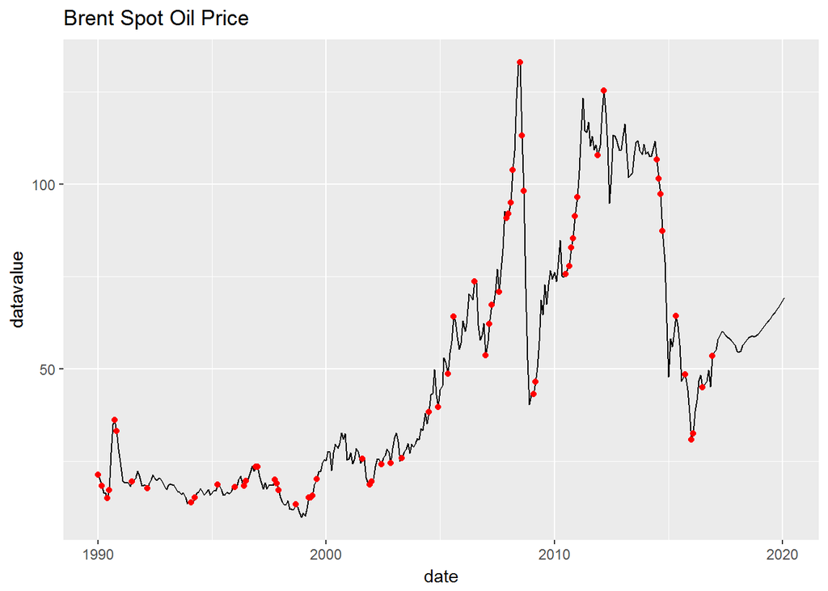

```r
dOut$date <- as.Date(dOut$date)
p1 <- p1 + geom_point(aes(x = date, y = value,group=1),size=1.5,color='red',
                           data = dOut)
p1
```

```r
#create an elemvated dummy time series for visualization only
dOut = mutate(dOut,value+5)
colnames(dOut) <- c('date','turning point','elevated')

djoin <- merge(dIn,dOut, by=c('date'),all=TRUE)
str(djoin)
```

```
## 'data.frame':    362 obs. of  4 variables:
##  $ date         : Date, format: "1990-01-01" "1990-02-01" ...
##  $ datavalue    : num  21.2 19.9 18.4 16.5 16.3 ...
##  $ turning point: num  21.2 NA 18.4 NA NA ...
##  $ elevated     : num  26.2 NA 23.4 NA NA ...
```

### Interactive exploration of the turning points

The javascript interactive graphic will enable us to zoom in and out the time series, also we can view the results by specifying the rolling window (rolling average smooth) in the lower-lest textbox. The bottom rangeselector also gives us a lot flexibility to view and validate the results.

```r
djoin_xts <- xts(djoin[,2:3],order.by = djoin[,1])
dygraph(djoin_xts,main = 'Brent Oil Price Turning Points(experiment)') %>% dyRangeSelector() %>% dySeries('datavalue',label='Brent Oil Price',drawPoints = FALSE,color='black') %>%
  dySeries('turning point', drawPoints = TRUE, color = 'red', pointSize = 2) %>%
  dyLegend(width=400,show='always', hideOnMouseOut = TRUE) %>% dyRoller(rollPeriod=1) %>%
  dyHighlight(highlightCircleSize = 5,
              highlightSeriesBackgroundAlpha = 0.8,
              hideOnMouseOut = FALSE)%>%
  dyEvent("2008-07-01",'Financial Crisis',labelLoc = 'bottom') %>%
  dyEvent("2008-12-01",'Bottom', labelLoc = 'bottom')
```

[interactive chart not shown]

```r
#drawxts <- xts(WTI[,3],order.by = WTI[,2])
#dxts <- xts(dIn[,-1],order.by = dIn[,1])
#dygraph(drawxts) #%>%
#dygraph(dxts,main='Brent Oil Price with Turning point (red)',xlab='Date') %>% dyRangeSelector()
```

### Algorithm TWO

Three consecutive changes above 5%. (Monthly data from IDDS.) In this algorithm, we add another layer: momentum. Also,if the same directional movement is seperated by 6 months, keep it too. In this case, we only keep the points with different previous sign.

```r
dIn <- WTI[,names(WTI)%in%c('date','datavalue')]
k = 3;
mag = 0.05;
numRec <- length(dIn[,2])
totalTP <- 0  # total number of turning points
TP_list <- list()
TP_direction <- list()
vout <- dIn[,2]
checkArray <- as.vector(matrix(0,nrow=k,ncol=1))
count <- 0
for(t in 1:(numRec-k)){
 #checkArray = as.vector(dIn[(t+1):(t+k),2] - dIn[t,2])
  checkArray = as.vector(diff(dIn[(t):(t+k),2])) # k consective same-direction change
  #print(checkArray)
 if(abs(sum(sign(checkArray)))==k & abs(checkArray[k]/dIn[t,2])>=mag) {
   # if duration >= k and absolute change >= mag
   currentDir <- sign(sum(sign(checkArray)))
   if(count == 0) {
     # insert first turning point to list
    count <-  count + 1
    TP_direction <- append(TP_direction,currentDir)
    TP_list <- append(TP_list,t)
   }else{
     # check the current turning point and previous tp
     # seperated more than k months and also different direction
     timeDiff <- t - as.integer(TP_list[count])
     if( (currentDir != as.integer(TP_direction[count])) ){
          count <- count + 1
          TP_direction <- append(TP_direction,currentDir)
          TP_list <- append(TP_list,t)
     }else{
          # 3rd layer of logic, keep turning points if it is seperated by more than k intervals
          if(timeDiff >= 6){
            count <- count + 1
            TP_direction <- append(TP_direction,currentDir)
            TP_list <- append(TP_list,t)
          }
        }
   }
 }else{
   vout <- NA
 }
}
TP_list = as.integer(as.vector(TP_list))
dOut <- data.frame(date=dIn[TP_list,1], value = dIn[TP_list,2])
dOutfull <- data.frame(data=dIn[,1], value = vout)
#create joined dataframe for input and output
colnames(dOut) <- c('date','turning point')
djoin <- merge(dIn,dOut, by=c('date'),all=TRUE)
```

### Visualize turning point algorithm2

```r
djoin_xts <- xts(djoin[,2:3],order.by = djoin[,1])
dygraph(djoin_xts,main = 'Brent Oil Price Turning Points(experiment)') %>% dyRangeSelector() %>% dySeries('datavalue',label='Brent Oil Price',drawPoints = FALSE,color='black') %>%
  dySeries('turning point', drawPoints = TRUE, color = 'red', pointSize = 2) %>%
  dyLegend(width=400,show='always', hideOnMouseOut = TRUE) %>% dyRoller(rollPeriod=1) %>%
  dyHighlight(highlightCircleSize = 5,
              highlightSeriesBackgroundAlpha = 0.8,
              hideOnMouseOut = FALSE)%>%
  dyEvent("2008-07-01",'Financial Crisis',labelLoc = 'bottom') %>%
  dyEvent("2008-12-01",'Bottom', labelLoc = 'bottom')
```

[interactive chart not shown]

### Algorithm Two Scenario Two: 2 months, 5%

Two consecutive changes above 5%. (Monthly data from IDDS.) In this algorithm, we add another layer: momentum. In this case, we only keep the points with different previous sign.

```r
dIn <- WTI[,names(WTI)%in%c('date','datavalue')]
k = 2;
mag = 0.05;
numRec <- length(dIn[,2])
totalTP <- 0  # total number of turning points
TP_list <- list()
TP_direction <- list()
vout <- dIn[,2]
checkArray <- as.vector(matrix(0,nrow=k,ncol=1))
count <- 0
for(t in 1:(numRec-k)){
 #checkArray = as.vector(dIn[(t+1):(t+k),2] - dIn[t,2])
  checkArray = as.vector(diff(dIn[(t):(t+k),2])) # k consective same-direction change
  #print(checkArray)
 if(abs(sum(sign(checkArray)))==k & abs(checkArray[k]/dIn[t,2])>=mag) {
   # if duration >= k and absolute change >= mag
   currentDir <- sign(sum(sign(checkArray)))
   if(count == 0) {
     # insert first turning point to list
    count <-  count + 1
    TP_direction <- append(TP_direction,currentDir)
    TP_list <- append(TP_list,t)
   }else{
     # check the current turning point and previous tp
     # seperated more than k months and also different direction
     timeDiff <- t - as.integer(TP_list[count])
     if( (currentDir != as.integer(TP_direction[count])) ){
          count <- count + 1
          TP_direction <- append(TP_direction,currentDir)
          TP_list <- append(TP_list,t)
     }else{
          # 3rd layer of logic, keep turning points if it is seperated by more than k intervals
          if(timeDiff >= 6){
            count <- count + 1
            TP_direction <- append(TP_direction,currentDir)
            TP_list <- append(TP_list,t)
          }
        }
   }
 }else{
   vout <- NA
 }
}
TP_list = as.integer(as.vector(TP_list))
dOut <- data.frame(date=dIn[TP_list,1], value = dIn[TP_list,2])
dOutfull <- data.frame(data=dIn[,1], value = vout)
#create joined dataframe for input and output
colnames(dOut) <- c('date','turning point')
djoin <- merge(dIn,dOut, by=c('date'),all=TRUE)
```

### Visualize turning point algorithm2 scenario 2

```r
djoin_xts <- xts(djoin[,2:3],order.by = djoin[,1])
dygraph(djoin_xts,main = 'Brent Oil Price Turning Points(experiment)') %>% dyRangeSelector() %>% dySeries('datavalue',label='Brent Oil Price',drawPoints = FALSE,color='black') %>%
  dySeries('turning point', drawPoints = TRUE, color = 'red', pointSize = 2) %>%
  dyLegend(width=400,show='always', hideOnMouseOut = TRUE) %>% dyRoller(rollPeriod=1) %>%
  dyHighlight(highlightCircleSize = 5,
              highlightSeriesBackgroundAlpha = 0.8,
              hideOnMouseOut = FALSE)%>%
  dyEvent("2008-07-01",'Financial Crisis',labelLoc = 'bottom') %>%
  dyEvent("2008-12-01",'Bottom', labelLoc = 'bottom')
```

[interactive chart not shown]